# Portfoliomanagement and Financial Analysis - Assignment 3

Submit until Monday 2020-10-07, 13:00

Maurizio, Sozzi

clear enviroment

```r
rm(list = ls())
```

```r
pacman::p_load(tidyverse,tidyquant,FFdownload,PortfolioAnalytics,tsibble,matrixcalc,Matrix,timetk,dplyr,devtools,ggrepel,readxl,ROI)
```

%>% to pipe

**Please** remember to put your assignment solutions in `rmd` format using **many** chunks and putting readable text in between, similar to my examples given in Research Methods and Assignment 1! Also, each student has to select his own set of 10 stocks having data available as of `2000-01-01`. Select by Sharpe-ratio, dominance or any other method (e.g. matching your first name).

## Exercise 1: Optimzing portfolios

Take your personal dataset of 10 stocks, set the time-frame to January 2000/ August 2018 (use a year-month format - either `as.yearmon` from `zoo` or `yearmonth` from `tsibble`) and calculate monthly simple returns (if you have not done so yet)! Use `pivot_wider()` and `tk_xts()` to make a `xts` (timeseries) from it (having ten columns with simple returns calculated from adjusted prices).

Getting 10 stocks: Apple (AAPL), Microsoft (MSFT), JPMorgan (JPM), Amazon (AMZN), 3M (MMM), Pfeizer (PFE), Bank of America (BAC), Intel (INTC), Exon Mobile (XOM) and IBM (IBM).

Get the stock prices of the stocks from 2000-01-01 to 2018-08-31

Create a vector with the stocks I want to observe

```r
stockselection <- c("AAPL", "MSFT", "JPM", "AMZN", "MMM", "PFE", "BAC", "INTC", "XOM", "IBM")

stockselection
```

```
 [1] "AAPL" "MSFT" "JPM"  "AMZN" "MMM"  "PFE"  "BAC"  "INTC" "XOM"  "IBM"
```

Get the stock prices

```r
stocks.prices <- stockselection %>%
  tq_get(get  = "stock.prices", from = "2000-01-01",to = "2018-08-31") %>%
  dplyr::group_by(symbol) #get all stock prices and sort them by symbol
stocks.prices
```

| symbol | date | open | high | low | close | volume | adjusted |
| --- | --- | --- | --- | --- | --- | --- | --- |
| AAPL | 2000-01-03 | 0.936384 | 1.004464 | 0.907924 | 0.999442 | 535796800 | 0.863657 |
| AAPL | 2000-01-04 | 0.966518 | 0.987723 | 0.903460 | 0.915179 | 512377600 | 0.790842 |
| AAPL | 2000-01-05 | 0.926339 | 0.987165 | 0.919643 | 0.928571 | 778321600 | 0.802415 |
| AAPL | 2000-01-06 | 0.947545 | 0.955357 | 0.848214 | 0.848214 | 767972800 | 0.732975 |
| AAPL | 2000-01-07 | 0.861607 | 0.901786 | 0.852679 | 0.888393 | 460734400 | 0.767695 |
| AAPL | 2000-01-10 | 0.910714 | 0.912946 | 0.845982 | 0.872768 | 505064000 | 0.754193 |
| AAPL | 2000-01-11 | 0.856585 | 0.887277 | 0.808036 | 0.828125 | 441548800 | 0.715615 |
| AAPL | 2000-01-12 | 0.848214 | 0.852679 | 0.772321 | 0.778460 | 976068800 | 0.672698 |
| AAPL | 2000-01-13 | 0.843610 | 0.881696 | 0.825893 | 0.863839 | 1032684800 | 0.746477 |
| AAPL | 2000-01-14 | 0.892857 | 0.912946 | 0.887277 | 0.896763 | 390376000 | 0.774928 |

[output cut: 990 more lines]

```r
NA
```

create monthly return for the 10 stocks. Make 10 columns for each stock one column with covmatrix.

```r
stocks.returns.monthly <- stocks.prices %>%
  mutate(date=as.yearmon(date))%>%
  tq_transmute(select = adjusted,
               mutate_fun = periodReturn,
               period="monthly",
               type="arithmetic",
               col_rename = "Stock.returns")


stocks.returns.monthly
```

| symbol | date | Stock.returns |
| --- | --- | --- |
| AAPL | Jan 2000 | -7.314362e-02 |
| AAPL | Feb 2000 | 1.048188e-01 |
| AAPL | Mar 2000 | 1.848422e-01 |
| AAPL | Apr 2000 | -8.651687e-02 |
| AAPL | May 2000 | -3.229218e-01 |
| AAPL | Jun 2000 | 2.470252e-01 |
| AAPL | Jul 2000 | -2.983289e-02 |
| AAPL | Aug 2000 | 1.992613e-01 |
| AAPL | Sep 2000 | -5.774356e-01 |
| AAPL | Oct 2000 | -2.402919e-01 |

[output cut: 990 more lines]

```r
stock.returns.timeseries.xts <- pivot_wider(data = stocks.returns.monthly, names_from = symbol, values_from = Stock.returns)%>%
  tk_xts(date_var = date, silent = TRUE)

stock.returns.timeseries.xts
```

```
                  AAPL         MSFT           JPM          AMZN           MMM           PFE
Jan 2000 -7.314362e-02 -0.160322148  0.1134687875 -0.2776223776 -7.946999e-03  0.1352942599
Feb 2000  1.048188e-01 -0.086845273 -0.0131682942  0.0667957406 -5.197636e-02 -0.1100104510
Mar 2000  1.848422e-01  0.188811759  0.0949762873 -0.0272232305  4.252269e-03  0.1381327981
Apr 2000 -8.651687e-02 -0.343529581 -0.1684444978 -0.1763059701 -2.187750e-02  0.1521364910
May 2000 -3.229218e-01 -0.103046650  0.0355284201 -0.1245753114 -3.684548e-03  0.0584450058
Jun 2000  2.470252e-01  0.278720782 -0.0748949822 -0.2483829237 -3.206988e-02  0.0786518600
Jul 2000 -2.983289e-02 -0.127343329  0.0889759937 -0.1703958692  8.509039e-02 -0.0963538147
Aug 2000  1.992613e-01  0.000000000  0.1217066423  0.3775933610  3.904711e-02 -0.0032680121
Sep 2000 -5.774356e-01 -0.136078896 -0.1733780176 -0.0737951807 -2.032581e-02  0.0412894861
Oct 2000 -2.402919e-01  0.141968849 -0.0080958203 -0.0471544715  6.035665e-02 -0.0386086128
Nov 2000 -1.565475e-01 -0.166968961 -0.1895600068 -0.3259385666  4.000986e-02  0.0282100723
Dec 2000 -9.848672e-02 -0.244008643  0.2322032769 -0.3696202532  2.065078e-01  0.0380820803
Jan 2001  4.537831e-01  0.407780531  0.2190999105  0.1124497992 -8.174291e-02 -0.0184783322
Feb 2001 -1.560697e-01 -0.033776845 -0.1514824166 -0.4115523466  2.437806e-02 -0.0008812727
Mar 2001  2.093126e-01 -0.073093343 -0.0377192387  0.0041717791 -7.849239e-02 -0.0900002477
Apr 2001  1.549640e-01  0.238857657  0.0774025256  0.5425219941  1.454284e-01  0.0573872448
May 2001 -2.173398e-01  0.021106619  0.0243852438  0.0576679975  1.472997e-03 -0.0069266416
Jun 2001  1.654117e-01  0.055218404 -0.0952191817 -0.1521869891 -3.778058e-02 -0.0662158181
Jul 2001 -1.918266e-01 -0.093287493 -0.0190275614 -0.1173144876 -1.945671e-02  0.0292133097
Aug 2001 -1.277462e-02 -0.138087411 -0.0900691601 -0.2842273819 -6.432869e-02 -0.0681008647
Sep 2001 -1.638800e-01 -0.103068033 -0.1332486301 -0.3322147651 -5.475468e-02  0.0467245790
Oct 2001  1.321698e-01  0.136408614  0.0455924026  0.1691792295  6.077198e-02  0.0448874062
Nov 2001  2.129875e-01  0.104213402  0.0667411455  0.6217765043  1.033916e-01  0.0363289109
Dec 2001  2.816704e-02  0.031770513 -0.0363196497 -0.0441696113  3.168162e-02 -0.0798893949
Jan 2002  1.287684e-01 -0.038339443 -0.0544294463  0.3114602588 -6.099362e-02  0.0456715350
Feb 2002 -1.221687e-01 -0.084288204 -0.1409692501 -0.0063424947  6.824292e-02 -0.0139261754
Mar 2002  9.078285e-02  0.033767567  0.2188033377  0.0141843972 -2.476037e-02 -0.0297848665
Apr 2002  2.534955e-02 -0.133477035 -0.0058552645  0.1671329371  9.381772e-02 -0.0853043084
May 2002 -3.996668e-02 -0.025832666  0.0242171102  0.0922707554  1.951015e-03 -0.0448210152
Jun 2002 -2.394867e-01  0.074445178 -0.0564674192 -0.1086121777 -1.937302e-02  0.0115617718
Jul 2002 -1.388249e-01 -0.122851681 -0.2560859557 -0.1107692308  2.300768e-02 -0.0757149942
Aug 2002 -3.342138e-02  0.022926274  0.0576924578  0.0339100346 -2.193623e-03  0.0267659247
Sep 2002 -1.695020e-02 -0.108801991 -0.2806818249  0.0662650602 -1.198877e-01 -0.1227325335
Oct 2002  1.082771e-01  0.222450945  0.1118304256  0.2153170747  1.543145e-01  0.0947619981
Nov 2002 -3.547103e-02  0.078735264  0.2130126203  0.2060949790  2.790254e-02 -0.0036960164
Dec 2002 -7.548258e-02 -0.103674995 -0.0464843479 -0.1910064668 -5.044313e-02 -0.0304472522
Jan 2003  2.093819e-03 -0.082012004 -0.0135250776  0.1566967261  1.013798e-02 -0.0020439351
Feb 2003  4.526378e-02  0.001947725 -0.0282777210  0.0073226545  1.185859e-02 -0.0177861594
Mar 2003 -5.796132e-02  0.021518873  0.0454148366  0.1826442980  3.716963e-02  0.0449363598
```

[output cut: 148 more lines]

```
Mar 2007  0.003737864 -0.0367576471  0.0525949159  0.0142023273
Apr 2007 -0.002352039  0.1238895001  0.0520876248  0.0843415805
May 2007  0.007286781  0.0369712138  0.0522680865  0.0470106340
Jun 2007 -0.035890502  0.0703334428  0.0085367940 -0.0126643827
Jul 2007 -0.030067674 -0.0050542994  0.0149024052  0.0513064198
Aug 2007  0.068747762  0.0952706825  0.0110742385  0.0583154139
Sep 2007  0.004495467  0.0042718875  0.0796685598  0.0095122127
Oct 2007 -0.039586083  0.0402168533 -0.0061582277 -0.0142611906
Nov 2007 -0.044531780 -0.0263786008 -0.0269964249 -0.0910003211
Dec 2007 -0.092582252  0.0222394668  0.0508080196  0.0277624523
Jan 2008  0.070043671 -0.2085520194 -0.0852814372 -0.0091583912
Feb 2008 -0.099886374 -0.0478057886  0.0196679406  0.0670837613
Mar 2008 -0.030042114  0.0605911203 -0.0279277821  0.0112418294
Apr 2008 -0.009760321  0.0509914141  0.1003783657  0.0482890280
 [ reached getOption("max.print") -- omitted 124 rows ]
```

1. As off now, we always perform the following steps before doing anything portfolio related: Check the summary/basic statistics and moments of the assets. Plot and check for (multivariate) normality (OPTIONAL). Check the correlations and do a scatterplot. Check the covariance/correlation structure.

?lapply

```r
stock.returns.timeseries.mu.xts <- lapply(stock.returns.timeseries.xts,FUN=mean)

stock.returns.timeseries.mu.xts
```

```
$AAPL
[1] 0.02619105

$MSFT
[1] 0.008428192

$JPM
[1] 0.01026497

$AMZN
[1] 0.02348643

$MMM
[1] 0.01031242

$PFE
[1] 0.005544591

$BAC
[1] 0.01015682

$INTC
[1] 0.007365497

$XOM
[1] 0.006625613

$IBM
[1] 0.005041548
```

Calculate sigma (standard deviation) for each stock

```r
stock.returns.timeseries.sigma.xts <- lapply(stock.returns.timeseries.xts,FUN=sd)

stock.returns.timeseries.sigma.xts
```

```
$AAPL
[1] 0.118072

$MSFT
[1] 0.08542982

$JPM
[1] 0.0881997

$AMZN
[1] 0.1389715

$MMM
[1] 0.05665511

$PFE
[1] 0.05603151

$BAC
[1] 0.1158198

$INTC
[1] 0.09815587

$XOM
[1] 0.04905955

$IBM
[1] 0.07036386
```

Calculate correlation matrix

```r
cormatrix <- cor(stock.returns.timeseries.xts)
cormatrix
```

```
            AAPL      MSFT       JPM       AMZN       MMM         PFE       BAC      INTC
AAPL 1.000000000 0.4633216 0.2697357 0.37957681 0.1967822 0.005292918 0.1720437 0.5684176
MSFT 0.463321604 1.0000000 0.4009392 0.40338093 0.1716807 0.176964028 0.2889329 0.4966098
JPM  0.269735721 0.4009392 1.0000000 0.25460415 0.3689778 0.352024888 0.6961547 0.3882892
AMZN 0.379576811 0.4033809 0.2546042 1.00000000 0.2834989 0.065774342 0.1278422 0.5088817
MMM  0.196782225 0.1716807 0.3689778 0.28349893 1.0000000 0.272577694 0.3765124 0.3063378
PFE  0.005292918 0.1769640 0.3520249 0.06577434 0.2725777 1.000000000 0.3678586 0.1416233
BAC  0.172043711 0.2889329 0.6961547 0.12784218 0.3765124 0.367858552 1.0000000 0.2417216
INTC 0.568417610 0.4966098 0.3882892 0.50888171 0.3063378 0.141623337 0.2417216 1.0000000
XOM  0.142896725 0.1917111 0.2260132 0.09178534 0.3035455 0.323478134 0.1354648 0.1209393
IBM  0.465411097 0.5117007 0.4749732 0.42241406 0.2939599 0.190826040 0.2697535 0.5552764
            XOM       IBM
AAPL 0.14289673 0.4654111
MSFT 0.19171107 0.5117007
JPM  0.22601321 0.4749732
AMZN 0.09178534 0.4224141
MMM  0.30354548 0.2939599
PFE  0.32347813 0.1908260
BAC  0.13546480 0.2697535
INTC 0.12093930 0.5552764
XOM  1.00000000 0.2449337
IBM  0.24493375 1.0000000
```

Plot the correlations

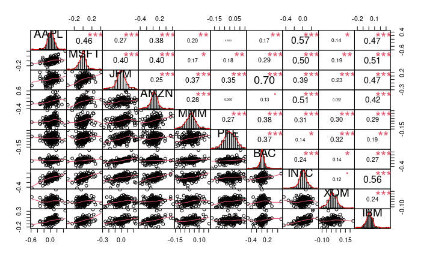

```r
chart.Correlation(R=stock.returns.timeseries.xts,method = "pearson"
                  )
```

Calculate the covariance matrix

```r
covmatrix <- cov(stock.returns.timeseries.xts, use = "everything", method = "pearson")
covmatrix
```

```
             AAPL         MSFT          JPM         AMZN          MMM          PFE          BAC
AAPL 1.394101e-02 0.0046734660 0.0028090056 0.0062283410 0.0013163520 3.501665e-05 0.0023527115
MSFT 4.673466e-03 0.0072982541 0.0030210306 0.0047890626 0.0008309407 8.470846e-04 0.0028588361
JPM  2.809006e-03 0.0030210306 0.0077791869 0.0031207448 0.0018437686 1.739694e-03 0.0071114090
AMZN 6.228341e-03 0.0047890626 0.0031207448 0.0193130707 0.0022321131 5.121704e-04 0.0020577028
MMM  1.316352e-03 0.0008309407 0.0018437686 0.0022321131 0.0032098019 8.652901e-04 0.0024705928
PFE  3.501665e-05 0.0008470846 0.0017396937 0.0005121704 0.0008652901 3.139530e-03 0.0023872395
BAC  2.352711e-03 0.0028588361 0.0071114090 0.0020577028 0.0024705928 2.387240e-03 0.0134142268
INTC 6.587655e-03 0.0041642911 0.0033615428 0.0069415871 0.0017035541 7.789031e-04 0.0027479867
XOM  8.277379e-04 0.0008034895 0.0009779676 0.0006257813 0.0008436969 8.892027e-04 0.0007697201
IBM  3.866637e-03 0.0030759210 0.0029477174 0.0041306052 0.0011718630 7.523495e-04 0.0021983635
             INTC          XOM          IBM
AAPL 0.0065876549 0.0008277379 0.0038666373
MSFT 0.0041642911 0.0008034895 0.0030759210
JPM  0.0033615428 0.0009779676 0.0029477174
AMZN 0.0069415871 0.0006257813 0.0041306052
MMM  0.0017035541 0.0008436969 0.0011718630
PFE  0.0007789031 0.0008892027 0.0007523495
BAC  0.0027479867 0.0007697201 0.0021983635
INTC 0.0096345747 0.0005823811 0.0038350862
XOM  0.0005823811 0.0024068393 0.0008455160
IBM  0.0038350862 0.0008455160 0.0049510728
```

2. Plot the average return of the assets against their standard deviation. Are there any dominated assets? Plot the efficient frontier using `chart.EfficientFrontier` and `chart.EF.Weights` (also check the `demo(demo_efficient_frontier)` from the `portfolioAnalytics`-package.

##Calculate mu and sigma and visualize them in a plot

```r
meanstocks <- stocks.returns.monthly %>%
    dplyr::group_by(symbol) %>%
    dplyr::summarize(mu = mean(Stock.returns, na.rm=TRUE))
stocks.returns.monthly
```

| symbol | date | Stock.returns |
| --- | --- | --- |
| AAPL | Jan 2000 | -7.314362e-02 |
| AAPL | Feb 2000 | 1.048188e-01 |
| AAPL | Mar 2000 | 1.848422e-01 |
| AAPL | Apr 2000 | -8.651687e-02 |
| AAPL | May 2000 | -3.229218e-01 |
| AAPL | Jun 2000 | 2.470252e-01 |
| AAPL | Jul 2000 | -2.983289e-02 |
| AAPL | Aug 2000 | 1.992613e-01 |
| AAPL | Sep 2000 | -5.774356e-01 |
| AAPL | Oct 2000 | -2.402919e-01 |

[output cut: 990 more lines]

```r
meanstocks
```

| symbol | mu |
| --- | --- |
| AAPL | 0.026191046 |
| AMZN | 0.023486434 |
| BAC | 0.010156820 |
| IBM | 0.005041548 |
| INTC | 0.007365497 |
| JPM | 0.010264965 |
| MMM | 0.010312422 |
| MSFT | 0.008428192 |
| PFE | 0.005544591 |
| XOM | 0.006625613 |

```r
sdstocks <- stocks.returns.monthly %>%
    dplyr::group_by(symbol) %>%
    dplyr::summarize(sigma = sd(Stock.returns, na.rm=TRUE))
sdstocks
```

| symbol | sigma |
| --- | --- |
| AAPL | 0.11807203 |
| AMZN | 0.13897147 |
| BAC | 0.11581980 |
| IBM | 0.07036386 |
| INTC | 0.09815587 |
| JPM | 0.08819970 |
| MMM | 0.05665511 |
| MSFT | 0.08542982 |
| PFE | 0.05603151 |
| XOM | 0.04905955 |

```r
 sigmamu <- left_join(sdstocks, meanstocks, by = "symbol")

sigmamu
```

| symbol | sigma | mu |
| --- | --- | --- |
| AAPL | 0.11807203 | 0.026191046 |
| AMZN | 0.13897147 | 0.023486434 |
| BAC | 0.11581980 | 0.010156820 |
| IBM | 0.07036386 | 0.005041548 |
| INTC | 0.09815587 | 0.007365497 |
| JPM | 0.08819970 | 0.010264965 |
| MMM | 0.05665511 | 0.010312422 |
| MSFT | 0.08542982 | 0.008428192 |
| PFE | 0.05603151 | 0.005544591 |
| XOM | 0.04905955 | 0.006625613 |

[figure not shown]

```r
sigmamuggplot <- ggplot(sigmamu, aes(sigma, mu))+
  geom_point()+
  geom_label_repel(aes(label = symbol),
                  box.padding   = 0.2,
                  point.padding = 0.1,
                  label.size = 0.2,
                  segment.color = 'grey50', size = 2.5)+
  theme_classic()

 sigmamuggplot
```

there is no asset which dominates all the other assets

3. Now comes the fun: Work through the vignette of the `portfolioAnalytics`-package (`vignette("portfolio_vignette")`), set a full investment constraint and limit the portfolio weights to be ‘long only’ and calculate minimum-variance/maximum-return and quadratic utility portfolios.

long only

```r
port <- portfolio.spec(assets = colnames(stock.returns.timeseries.xts),
                       category_labels = stockselection)
port <- add.constraint(portfolio=port, type="long_only")

meanvar.portf <- add.objective(portfolio=port, type="return", name="mean")
meanvar.portf <- add.objective(portfolio=port, type="risk", name="StdDev")

summary(meanvar.portf, digits=2)
```

```
$category_labels
$category_labels$AAPL
[1] 1

$category_labels$MSFT
[1] 2

$category_labels$JPM
[1] 3

$category_labels$AMZN
[1] 4

$category_labels$MMM
[1] 5

$category_labels$PFE
[1] 6

$category_labels$BAC
[1] 7

$category_labels$INTC
[1] 8

$category_labels$XOM
[1] 9

$category_labels$IBM
[1] 10


$assets
AAPL MSFT  JPM AMZN  MMM  PFE  BAC INTC  XOM  IBM
 0.1  0.1  0.1  0.1  0.1  0.1  0.1  0.1  0.1  0.1

$enabled_constraints
$enabled_constraints[[1]]
An object containing 5 nonlinear constraints.

```

[output cut: 20 more lines]

```
$multiplier
[1] 1

$call
add.objective(portfolio = port, type = "risk", name = "StdDev")

attr(,"class")
[1] "portfolio_risk_objective" "objective"


$disabled_objectives
list()

attr(,"class")
[1] "summary.portfolio"
```

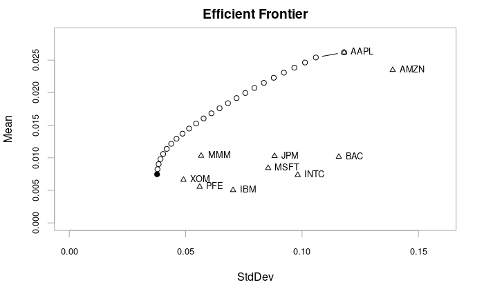

```r
prt_ef <- create.EfficientFrontier(R=stock.returns.timeseries.xts, portfolio=port, type="mean-StdDev", match.col = "StdDev")


chart.EfficientFrontier(prt_ef, match.col="StdDev", type="b", rf=NULL, pch.assets = 2)
```

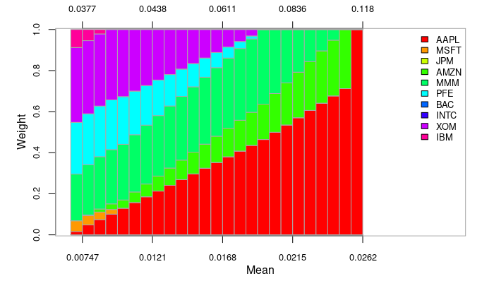

```r
chart.EF.Weights(prt_ef, colorset=rainbow(n = length(stockselection)), match.col="StdDev", cex.lab = 1
, main = "StdDev")
```

full investment

```r
portfull <- portfolio.spec(assets = colnames(stock.returns.timeseries.xts))

portfull <- add.constraint(portfolio=portfull, type="full_investment")

meanvar.portf.full <- add.objective(portfolio=portfull, type="return", name="mean")
meanvar.portf.full <- add.objective(portfolio=portfull, type="risk", name="StdDev")

prt_ef_full <- create.EfficientFrontier(R=stock.returns.timeseries.xts, portfolio=portfull, type="mean-StdDev", match.col = "StdDev")
```

```
Inf or -Inf values detected in box constraints, maximum return
            objectives must have finite box constraint values.
```

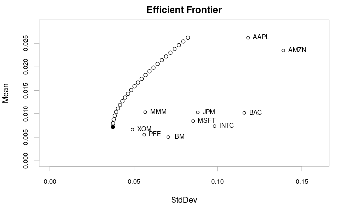

```r
chart.EfficientFrontier(prt_ef_full, match.col="StdDev", type="b", rf=NULL, pch.assets = 1)
```

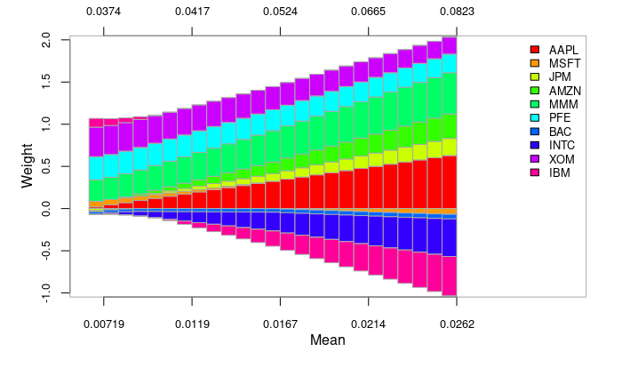

```r
chart.EF.Weights(prt_ef_full, colorset=rainbow(n = length(stockselection)), match.col="StdDev", cex.lab = 1, main = "StdDev")
```

Minimum varriance

```r
port_l <- portfolio.spec(assets = colnames(stock.returns.timeseries.xts))

port_l <- add.constraint(portfolio = port_l,
type = "long_only")

minvar <- add.objective(portfolio = port_l, type = "risk", name = "var")

opt_minvar <- optimize.portfolio(R=stock.returns.timeseries.xts, portfolio = minvar, optimize_method = "ROI", trace = TRUE)

print(opt_minvar)
```

```
PortfolioAnalytics Optimization

Call:
optimize.portfolio(R = stock.returns.timeseries.xts, portfolio = minvar,
    optimize_method = "ROI", trace = TRUE)

Optimal Weights:
  AAPL   MSFT    JPM   AMZN    MMM    PFE    BAC   INTC    XOM    IBM
0.0165 0.0521 0.0000 0.0000 0.2272 0.2520 0.0000 0.0000 0.3644 0.0878

Objective Measure:
 StdDev
0.03772
```